# Evaluation report and metrics

6.0.0  
Evaluation report and metrics

- [ Index ]
- Introduction
  - Evaluated metrics
  - Computation of the metrics
  - And for the quantized models?
  - “–no–exec-model” option
  - Specific attention on the provided data
  - Random data generation
  - ONNX model support
  - Classifier and regressor models
  - Input validation files
  - Output validation files for post-processing
- Metrics
  - Computational complexity: MACC and cycles/MACC
  - Memory-related metrics
  - Classification accuracy (acc)
  - Root Mean Square Error (rmse)
  - Mean Absolute Error (mae)
  - L2 relative error (l2r)
  - Confusion matrix (CM)
- Examples
  - 32b floating point model
  - Quantized model
  - Quantized keras model
  - Model with multiple IO
- Post-processing example
- References
- Revision history

# Evaluation report and metrics

X-CUBE-AI Expansion Package

r2.0

AI PLATFORM r6.0.0 (Embedded Inference Client API 1.1.0)

Command Line Interface r1.4.1

# Introduction

This article describes the different metrics (and associated computing flow) which are used to evaluate the performance of the generated C-files (or C-model). Proposed metrics should be considered as the generic indicators which allows to compare numerically the predictions of the c-model against the predictions of the original model. Only the scalar values are computed, no specific threshold or post-process are used. For advanced performance evaluation, all injected and predicted data (including the data from the original model) are saved.

Be aware, that the underlying validation engine has not been designed and optimized, in term of execution time and host resource usage, to valid a pre-trained model as during a training/test phase. A representative and small sub-set of the whole training data set is expected to test the exactness of the generated C-model running on the desktop/X86 or STM32 run-time.

## Evaluated metrics

| metric | category | description | applicable to |
| --- | --- | --- | --- |
| MACC | complexity | computational complexity | all models |
| ROM/RAM | memory | memory-related metrics | all models |
| ACC | perf | accuracy (Classification accuracy) | only classifier models (float and integer format) |
| RMSE | perf | Root Mean Square Error | all models |
| MAE | perf | Mean Absolute Error | all models |
| L2r | perf | L2 relative Error | all models |
| CM | perf | Confusion Matrix | only classifier models (float and integer format) |

## Computation of the metrics

The MACC and ROM/RAM metrics are processed during the import of the model. The other metrics are evaluated during the process of validation (i.e. `'validate'` command). By default, no user data are requested (default mode), the models are feed with the random data. However, to be more precise, the user has the possibility to give a representative pre-processed data set (with or without the references). Raw input and output data are always saved in a dedicated file which could be used by a post-process user script.

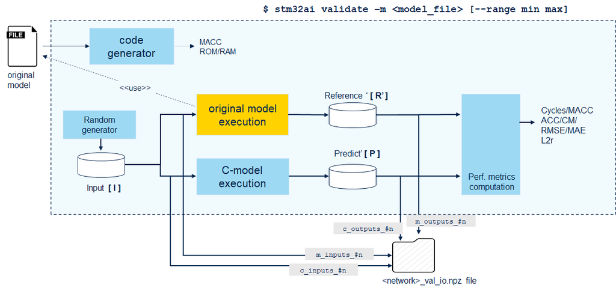

Figure 1: Computation of the metrics (default mode)

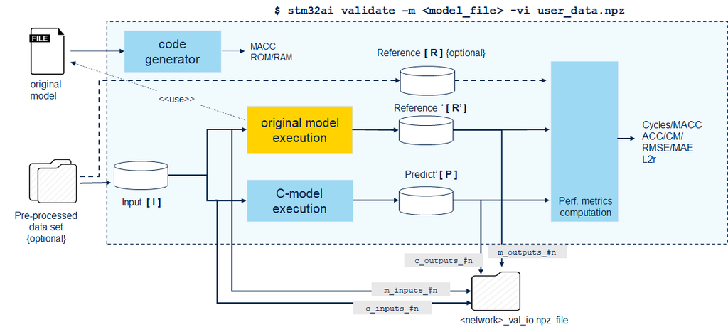

Figure 2: Computation of the metrics (with user data)

- **[ I ]** designates the list of the pre-processed samples (or inputs) which are used to feed the original model and the C-model. It can be provided by the user (see “Inputs validation files” and “Specific attention on the provided data” sections) or randomly generated (see “Random data generation” section). They are used as-is without pre-processing with a potential exception for the quantized models.
- **[ P ]** designates the list of the predicted samples inferred by the C-model.
- **[ R’ ]** designates the list of the predicted samples inferred by the original model.
- {optional} **[ R ]** designates, the list of the predicted output samples provided by the user which will be used as ground truth or reference values.

At the end of the process, metrics are summarized in a simple table.

```
Evaluation report (summary)
----------------------------------------------------------------------------------------------------------
Mode                 acc      rmse      mae       l2r       tensor
----------------------------------------------------------------------------------------------------------
x86 C-model #1       92.68%   0.053623  0.005785  0.340042  dense_4_nl [ai_float, [(1, 1, 36)], m_id=[10]]
original model #1    92.68%   0.053623  0.005785  0.340042  dense_4_nl [ai_float, [(1, 1, 36)], m_id=[10]]
X-cross #1           100.00%  0.000000  0.000000  0.000000  dense_4_nl [ai_float, [(1, 1, 36)], m_id=[10]]
----------------------------------------------------------------------------------------------------------
```

- *X-cross #1* indicates the metrics which are evaluated with the **[ P ]** and **[ R’ ]** data for the first output #1 (there is one line by output). In this case, the predicted values **[ R’ ]** are considered as the **references**.
- *x86 [or stm32] C-model* (respectively *original model*) designates the case where **[ R ]** data are also provided by the user allowing to compute the metrics against theses references or ground truth values. If **[ R ]** is not provided only *X-cross #1* metrics are computed.

When the generated c-model is executed on the STM32 device through the AI Validation project (refer to [[UM]](https://www.st.com/resource/en/user_manual/dm00570145.pdf)), the same validation flow is applied.

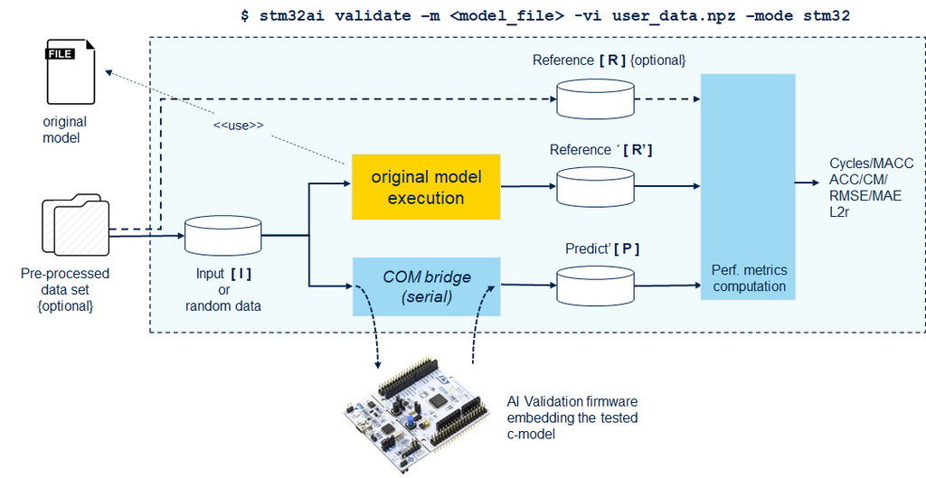

Figure 3: Computation of the metric (STM32 case)

## And for the quantized models?

No specific metrics are defined for the quantized models. The same metrics are processed for a quantized model or not, with or without input/output in integer. Be aware that the metrics are **always** computed with the `float32` data types. If the data type is `int8` (or `uint8`), data are de-quantized before. The same scale/zero-point values from the original model are used for all the data: **[ P ]**, **[ R’ ]** and **[ R ]**. Symmetrically, if `float32` data type are provided, data are quantized before to feed the model.

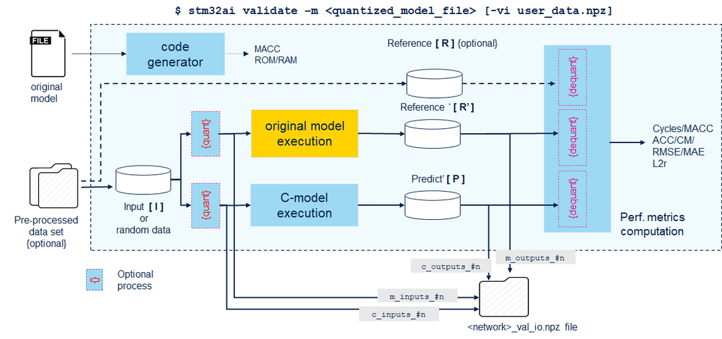

Figure 4: Computation of the metrics (quantized models)

**Note** — If `uint8` data type are provided, and the requested quantized model expects `int8` or `float32` type an exception will be raised. Data importer is not able to convert the data to the expected format.

## “–no–exec-model” option

The `'--no-exec-model'` option allows to perform the validation flow w/o the execution of the original model. This can be considered as a workaround when sometimes a particular model can be imported and generated but the associated inference engine embedded in the pack is not compatible or older. The other interest is to improve the execution time when only the predicted data by the c-model are requested.

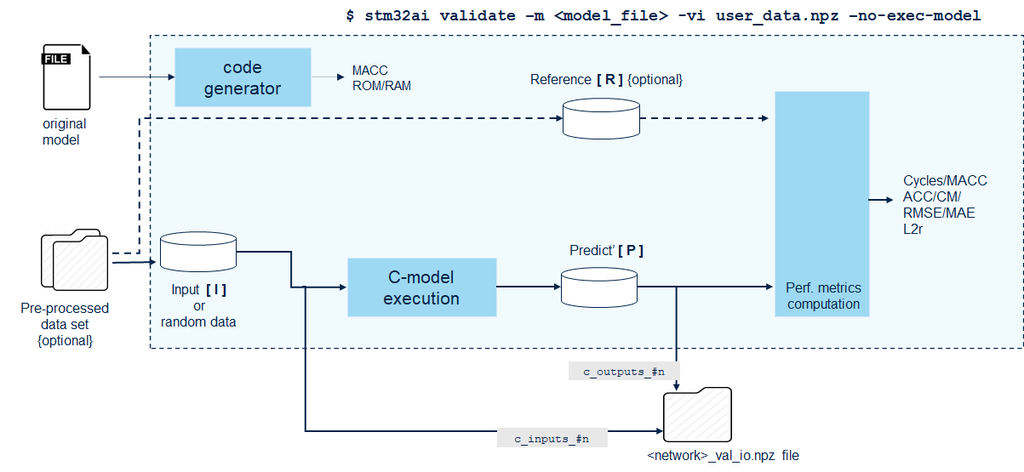

Figure 5: –no-exec-model option

## Specific attention on the provided data

To have an accurate validation process or more significant metrics, it is important to feed the original model and the generated c-model with closest data to the validating data set used to to test the original model. If the raw data set have been pre-processed, the user should build a representative data set with a sub-set of these pre-processed data.

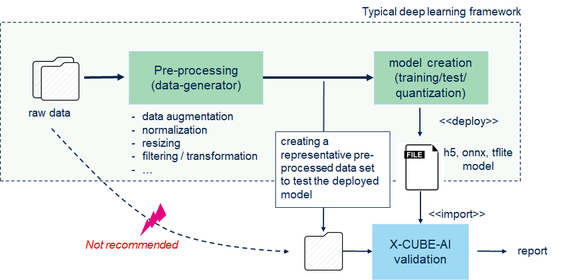

Figure 6: Representative data set creation

This recommendation is also applicable for the output data. For the computation of the metrics are based on the element-wise operations between the provided references and the predicted values. For a classifier (one or multiple classes) for example, one-hot encoding data can be provided. Integer Encoding is not supported.

The following figure illustrates a typical example, where a particular attention is requested. The STM32Cube function pack for computer vision (https://www.st.com/en/embedded-software/fp-ai-vision1.html) provides an advanced debug mode which allows to inject or to dump the pre-processed images. If the user wants to valid its pre-trained model with the X-CUBE-AI validation engine and to compare with the deployed model, he must ensure that the format and the applied pre-processing are similar to have the more accurate validation metrics. In this use-case, to take account the pre-processing done by the pack, it is recommended to create a set of representative pre-processed images to test different models off-line or to refine an existing pre-trained model.

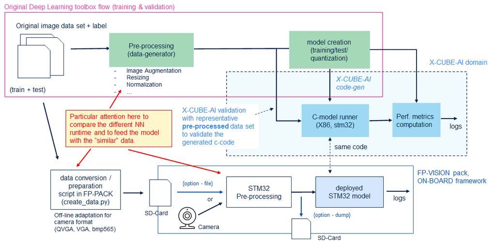

Figure 7: Validation against the FP-Vision

## Random data generation

When no user data are provided, random data are generated. By default, the value are uniformly distributed with a fixed seed in the range `[0.0, 1.0[`. The user has the possibility to change the min and max values with the `--range` option. During the validation process, min/max/mean and std values for the different input and outputs are reported.

To generate a batch of 20 samples by inputs with the data which are uniformly distributed between -10 and 5.

```bash
$ stm32ai validate <model_file> --range -10 5 -b 20
...
Setting validation data...
 generating random data - batch_size=20 rnd_range=[-10.0, 5.0]
 input definitions:
  0: shape=(20, 1, 1, 99), dtype=float32, min/max=[-9.952, 4.996], mean/std=[-2.513, 4.383]
...
```

If the model has the inputs in integer (`'int8'` or `'uint8'`), the min and max value are automatically inferred with the associated scale and zero-point values to be sure to have an uniform distribution between the min/max values of the input data type (i.e. `[-128, 127]` for `int8` type).

```
$ stm32ai validate <quant_model_file>
...
Setting validation data...
 generating random data - batch_size=10
 input definitions:
  0: shape=(10, 49, 40, 1), dtype=uint8, min/max=[0, 255], mean/std=[127.323, 73.590], scale=0.10196070 zp=0
...
```

## ONNX model support

Data format of the generated C-model are **always** channel last (or NHWC data format). Consequently, for the validation of the imported ONNX model (which is channel first or NCHW), the data should be previously transposed (CHW -> HWC) by the user to build the representative data set. This is also requested to use the embedded inference C-API [API].

## Classifier and regressor models

No specific metrics are defined for the regressor models. ACC and CM metrics are only evaluated if the predicted outputs **[ R’ ]** (or **[ R ]**) may represent probabilities within a given tolerance. Nevertheless, the `'--classifier'` option can be used to force the computation of the `'ACC` and `CM'` metrics.

```
$ stm32ai validate -m <regressor_model_file>
...
Evaluation report (summary)
-------------------------------------------------------------------------------------------------------
Mode         acc    rmse          mae           l2r           tensor
-------------------------------------------------------------------------------------------------------
X-cross #1   n.a.   0.000000065   0.000000048   0.000000127   dense_2, ai_float, [(1, 1, 1)], m_id=[2]
-------------------------------------------------------------------------------------------------------
```

## Input validation files

The user can provide the inputs and associated ground truth or reference values in a simple file (npz file) or separated files (npy or csv files). During the import of the data, each array is reshaped according the shape of the input (respectively output) of the c-model. Only float32 and int8/uint8 data type are supported.

[output not shown]

- for the csv files, a particular tag (`'dtype=uint8'` or `'dtype=int8'`) must be defined inside the five first comment lines to indicate the type of the data, else float32 data type will be considered.

  ```
  # Example of csv file (32-b float number)
  # comment line
  -1.076007485389709473e+00,6.278980255126953125e+00,.. 3.949900865554809570e+00
  1.160453605651855469e+01,1.707991600036621094e+01,.. 1.334794044494628906e+00
  ...
  ```

  ```
  # Example of csv file (uint8 number)
  # dtype=uint8
  50, 65, 71, 71
  4.800000000000000000e+01,6.700000000000000000e+01,7.300000000000000000e+01,6.700000000000000000e+01
  ...
  ```

- lines in the `'csv'` file are always parsed as the 32b float, after they are converted to int8/uint8 type if requested.
- for a model with multiple IOs, one csv file should be strictly provided by input (respectively by output). The order in the CLI is used to know the order, name of the file is not considered. For the `npz` file, the index `<idx>` in the key name will be used.

  ```
  $ stm32ai validate <model_file> -vi inputs_one.csv inputs_two.csv -vo outputs.csv
  ```

For information, when the user data set are loaded, type and shape are reported:

```
...
Setting validation data...
using file: <output-directory-path>\network_val_io.npz
input definitions:
  0: shape=(10, 128, 8, 1), dtype=float32, min/max=[0.000, 1.000], mean/std=[0.494, 0.288]
output definitions:
  0: shape=(10, 1, 1, 50), dtype=float32, min/max=[-143.704, 27.435], mean/std=[-40.943, 33.836]
...
```

**Note** — Generated output validation files from a previous “validate” command can be used as input files.

## Output validation files for post-processing

Inputs and predicted values are saved in different files without modifications (type and shape are conserved). This allows to use a post-processing script to compute the user-defined metrics.

```
<output-directory-path>\<name>_val_io.npz
```

The `npz` file is a standard numpy binary format storing several arrays. The following key entries are used to store the data: `'m_inputs_<idx>'`, `'c_inputs_<idx>'`, `'m_outputs_<idx>'` and `'c_outputs_<idx>'`.

For quick and easy debug purpose, `'csv'` files (txt file) are also created by input and output. However, the number of samples and data by sample is voluntarily limited to limit the execution time. By default, only the 128 first samples with a size lower that 512 items are saved. If the limit is exceeded, file is created but without the data. `'--save-csv'` option can be used to force the creation of the `'csv'` files with all the data. The created `'csv'` file respects the format of the input validation files. The name of file is defined as follow:

```
<network_name>_[m,c]_[inputs,outputs]_<idx>.csv
```

```
$ stm32ai validate <model_file> -v 2 --save-csv
...
Saving data in the "<output-directory-path>" directory
 creating the file: network_val_io.npz with all data
 creating the file: network_val_m_inputs_1.csv
 creating the file: network_val_m_outputs_1.csv
 m_outputs_1: shape=(10, 1, 1, 50), dtype=float32, min/max=[-143.704, 27.435], mean/std=[-40.943, 33.836]
 creating the file: network_val_c_inputs_1.csv
 creating the file: network_val_c_outputs_1.csv
 c_outputs_1: shape=(10, 1, 1, 50), dtype=float32, min/max=[-143.704, 27.435], mean/std=[-40.943, 33.836]
...
```

# Metrics

## Computational complexity: MACC and cycles/MACC

During the analyzing step of the model, global computational complexity is displayed and logged: `'MACC'` (refer to [CLI], “Analyze command” section). It indicates the number of multiply-and-accumulate operations which are requested to perform an inference. Value is computed independently of the data format (floating-point or integer) or the underlying C-implementation. As illustrated in the report (“graph” section, table form), value of the MACC can be refined layer-per-layer according the applied optimizations (fusing and/or folding processes).

Like this metric impacts directly, the latency of the application, on-device profiling is possible thanks to the *aiSystemPerformance* or *aiValidation* test applications [[UM]](https://www.st.com/resource/en/user_manual/dm00570145.pdf). They permit to report the average number of CPU clocks requested for the whole C-model allowing to compute the number of requested *cycles by MACC*. This indicator highlights the *global efficiency* of the underlying C-implementation, including the HW platform setting aspects. With the validation on-device, the execution-time by layer [CLI] is also evaluated.

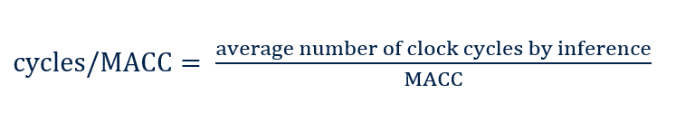

```
...
Results for 10 inference(s) @480/240MHz (macc:336084)
 device      : 0x450/STM32H743/753 and STM32H750 @480MHz/240MHz (FPU is present) lat=4 Core:I$/D$
 duration    : 4.522 ms (average)
 CPU cycles  : 2170476 (average)
 cycles/MACC : 6.46 (average for all layers)
...
```

Be aware that no theoretical relation is defined between the reported complexity and the real performance of the implemented C-model, due to the variability of the targeted environments considering the used Arm® tool-chains, MCU and underlying sub-system memory settings, NN topologies and layers. It is difficult to provide off-line an accurate number of CPU cycles/MACC vs. a given STM32 system settings. However, out-of-the-box, the following rough estimations can be used for a 32-bit floating-point C-model.

| STM32 series based on | cycles/MACC |
| --- | --- |
| Arm® Cortex®-M4 | ~9 |
| Arm® Cortex®-M7 | ~6 |

For the quantized models, this factor can be approximately divided by 2 on average.

## Memory-related metrics

### Main contributors

To deploy a model in a resource-constrained runtime environment, the requested ROM and RAM sizes are the key factors. Two main static memory contributors are directly reported through the fields: `'weights (ro)'` and `'activations (rw)'` (refer to [CLI], “Analyze command” section). The first (also called `ROM`) designates the size in bytes requested to store the weights/bias. They are generally placed in a read-only memory-mapped segment like the embedded STM32 flash memory (`.rodata` section). Second (also called `RAM` or activations buffer) designates the size in bytes requested to store the intermediate results. It can be considered as a private heap (or scratch buffer) only used by the C-runtime during an inference. It should ba placed in a read-write memory-mapped segment like the embedded STM32 RAM memory (`.bss, .data or .heap sections).

**Note** – The “AI buffers and privileged placement” section provides more details about the integration aspects.

### With the kernel code/data sizes

To have a complete view, by refining all AI contributors, the relocatable binary support (refer to [RELOC]) can be used. The generated report allows to have more details about the real requested memory usage to execute the AI stack. It includes also the requested size of the data and code sections for the used kernels (part of the STM32 network runtime library) and the size for the generated C-structure and parameters for a given model (part of the generated `network.c` file).

In the following table, only the AI contributors are considered for each code/data sections. `weights` section designates the section to store the weights/bias and `act. size` indicates the size of the activations buffer.

```
Runtime memory layout (series="stm32f4")
--------------------------------------------------------------------------------
section      size (bytes)
--------------------------------------------------------------------------------
header                100 *
txt                 7,864      network+kernel
rodata                128      network+kernel
data                1,756      network+kernel
bss                   132      network+kernel
got                   108 *
rel                   504 *
weights            15,560      network
--------------------------------------------------------------------------------
flash size         25,308 + 712 (+2.81%) *
ram size            1,888 + 108 (+5.72%) *
--------------------------------------------------------------------------------
bin size           26,024      binary image
act. size             192      activations buffer

(*) extra bytes for relocatable support
```

### System heap and stack size

By construction, the kernels are designed to not use the system heap (no explicit call to `malloc/free` like functions). A minimal stack is requested to use the runtime. The *aiSystemPerformance* test application has been designed to know the minimal stack size.

## Classification accuracy (acc)

For classifier model type, *Classification accuracy* is what we usually mean, when the term *accuracy* is used. *ACC* is the ratio between of correct predictions to the total number of inputs. This indicator evaluates the performance of the *classifier* model, if a *regressor* type is passed, the *ACC* is **NOT** calculated and `n.a.` value is reported.

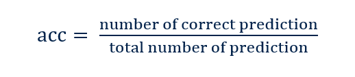

**Note** – No threshold is applied to determine if a given class is detected or not. Only the maximum value along the axis is used.

```python
import numpy as np
from sklearn.metrics import accuracy_score

def acc(ref, pred):
  """Classification accuracy (ACC)."""
  return accuracy_score(np.argmax(ref, axis=1), np.argmax(pred, axis=1))
```

## Root Mean Square Error (rmse)

*RMSE* is quite similar to *MAE*, the only difference being that *RMSE* takes the average of the square of the difference between the original values and the predicted values. As, we take square of the error, the effect of larger errors become more pronounced then smaller error, hence the model can now focus more on the larger errors. *RMSE* is computed for the flattened array (element-wise along the array), returning a scalar value. If **[ R ]** is not provided **[ R’ ]** is used.

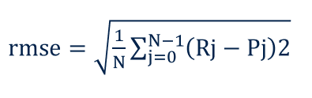

```python
import numpy as np

def rmse(ref, pred):
  """Return Root Mean Squared Error (RMSE)."""
  return np.sqrt(((ref - pred).astype(np.float64) ** 2).mean())
```

## Mean Absolute Error (mae)

*MAE* is the average of the difference between the original value (or reference value, Rj) and the predicted value Pj. It gives the measure of how far the predictions were from the actual output. However, they don’t gives any idea of the direction of the error i.e. whether we are under predicting the data or over predicting the data. *MAE* is computed for the flattened array (element-wise along the array), returning a scalar value. If **[ R ]** is not provided **[ R’ ]** is used.

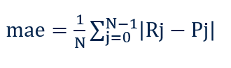

```python
import numpy as np

def mae(ref, pred):
  """Return Mean Absolute Error (MAE)."""
  return (np.abs(ref - pred).astype(np.float64)).mean()
```

## L2 relative error (l2r)

*L2r* is the scalar value of the relative 2-norm or Euclidean distance between the generated values of the original model **[ R’ ]** and the C-model **[ P ]**. When possible, this metric is also reported for the output of a C-layer matching with the original layer (see [CLI] “Extended complexity report per layer” section).

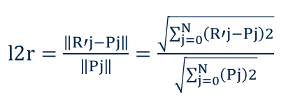

```python
import numpy as np

def l2r(ref, pred):
  """Compute L2 relative error"""
  def magnitude(v):
    return np.sqrt(np.sum(np.square(v).flatten()))
  mag = magnitude(pred) + np.finfo(np.float32).eps
  return magnitude(ref - pred) / mag
```

## Confusion matrix (CM)

When outputs are provided and the model is considered as a classifier, a confusion matrix is displayed and logged for the C-model and the reference model. It describes the complete performance of the model. Note that if a *regressor* type is passed, the confusion matrix is **NOT** calculated only the RMSE, MAE and L2r metrics are computed.

```
8 classes (50 samples)
------------------------------------------------
C0         4    .    .    .    .    .    .    .
C1         .    9    .    .    .    .    .    .
C2         .    .    6    .    .    .    .    .
C3         .    .    .    7    .    .    .    .
C4         .    .    .    .    5    .    .    .
C5         .    .    .    .    .    6    .    .
C6         .    .    .    .    .    .    7    .
C7         .    .    .    .    .    .    .    6
```

*X-Cross* confusion matrix or accuracy uses the outputs of the reference model to build the ground truth values. They are used to evaluate and to compare the performance of the C-model.

**Note** — The confusion matrix is only displayed when the number of class is lower or equal to 20.

# Examples

## 32b floating point model

### with random data

This section illustrates a case where a 32b floating point model (traditional DS-CNN mnist example) is validated with the random data. Default range `[0, 1.0]` is used here, because the image data set has been normalized between 0 and 1 (see `'/ 255.0'` statement in the snipped code). *X-cross #1* results highlights that the predicted values of both models are close (`l2r = 2.56732528e-06`).

```python
import tensorflow as tf
import numpy as np

H, W, C = 28, 28, 1
IN_SHAPE = (H, W, C)
NB_CLASSES = 10

def load_data_set():
  """Load the data"""

  mnist = tf.keras.datasets.mnist
  (train_images, train_labels), (test_images, test_labels) = mnist.load_data()

  # Normalize the input image so that each pixel value is between 0 to 1.
  x_train = x_train / 255.0
  x_test = x_test / 255.0

  x_train = x_train.reshape(x_train.shape[0], H, W, C).astype(np.float32)
  x_test = x_test.reshape(x_test.shape[0], H, W, C).astype(np.float32)

  # convert class vectors to binary class matrices
  y_train = tf.keras.utils.to_categorical(y_train, NB_CLASSES)
  y_test = tf.keras.utils.to_categorical(y_test, NB_CLASSES)

  return x_train, y_train, x_test, y_test

def build_model():
  """Define the model"""

  model = tf.keras.Sequential([
    tf.keras.layers.InputLayer(input_shape=IN_SHAPE),
    tf.keras.layers.Conv2D(filters=12, kernel_size=(3, 3), activation=tf.nn.relu),
    tf.keras.layers.MaxPooling2D(pool_size=(2, 2)),
    tf.keras.layers.Dropout(0.5),
    tf.keras.layers.Flatten(),
    tf.keras.layers.Dense(10, activation='softmax')
  ])

  return model
```

```
$ stm32ai validate <model_fp32> --classifier
Neural Network Tools for STM32AI v1.4.1 (STM.ai v6.0.0)

Setting validation data...
 generating random data - batch_size=10
 input definitions:
  0: shape=(10, 28, 28, 1), dtype=float32, min/max=[0.000, 1.000], mean/std=[0.495, 0.289]

Running the X86 model (IO mode)...

Running the Keras model...

Saving data in the "<output-directory-path>" directory
 creating the file: network_val_io.npz with all data
 m_outputs_1: shape=(10, 1, 1, 10), dtype=float32, min/max=[0.000, 0.979], mean/std=[0.100, 0.230]
 c_outputs_1: shape=(10, 1, 1, 10), dtype=float32, min/max=[0.000, 0.979], mean/std=[0.100, 0.230]

Computing the metrics...

Cross accuracy report #1 (reference vs C-model)
----------------------------------------------------------------------------------------------------
NOTE: the output of the reference model is used as ground truth/reference value

 acc=100.00%, rmse=0.000000643, mae=0.000000262, l2r=0.000002567

 10 classes (10 samples)
 ----------------------------------------------------------
 C0        0    .    .    .    .    .    .    .    .    .
 C1        .    0    .    .    .    .    .    .    .    .
 C2        .    .    0    .    .    .    .    .    .    .
 C3        .    .    .    9    .    .    .    .    .    .
 C4        .    .    .    .    0    .    .    .    .    .
 C5        .    .    .    .    .    1    .    .    .    .
 C6        .    .    .    .    .    .    0    .    .    .
 C7        .    .    .    .    .    .    .    0    .    .
 C8        .    .    .    .    .    .    .    .    0    .
 C9        .    .    .    .    .    .    .    .    .    0


Evaluation report (summary)
------------------------------------------------------------------------------------------------------------
Mode         acc       rmse          mae           l2r           tensor
------------------------------------------------------------------------------------------------------------
X-cross #1   100.00%   0.000000643   0.000000262   0.000002567   dense_nl, ai_float, [(1, 1, 10)], m_id=[4]
------------------------------------------------------------------------------------------------------------

X-cross (l2r) #1 error : 2.56732528e-06 (expected to be < 0.01)

Creating report file <output-directory-path>\network_validate_report.txt
```

### with representative user data set

When a representative user data set is used (including the ground truth values), the `ACC/CM` metrics are now evaluated with the original and generated c-models. As for the random data, *X-cross #1* results highlights that the predicted values of both models are close (`l2r = 1.78341338e-07`). Note that here, the *x86 C-model #1* and *original model #1* results indicate the relatively important `rmse/mae/l2r` errors. These errors are due here to the encoding of the provided ground truth values, here one-hot encoded: `[0.0 0.0 1.0 .. 0.0]`. These errors could be more huge, if no *softmax* layer is present.

```
$ stm32ai validate <model_fp32> --classifier -vi mnist_reduced_test.npz
Neural Network Tools for STM32AI v1.4.1 (STM.ai v6.0.0)

Setting validation data...
 using file: C:\ai_lab\datasets\mnist_test.npz
 input definitions:
  0: shape=(128, 28, 28, 1), dtype=float32, min/max=[0.000, 1.000], mean/std=[0.139, 0.318]
 output definitions:
  0: shape=(128, 1, 1, 10), dtype=float32, min/max=[0.000, 1.000], mean/std=[0.100, 0.300]

Running the X86 model (IO mode)...

Running the Keras model...

Saving data in the "<output-directory-path>" directory
 creating the file: network_val_io.npz with all data
 m_outputs_1: shape=(128, 1, 1, 10), dtype=float32, min/max=[0.000, 1.000], mean/std=[0.100, 0.285]
 c_outputs_1: shape=(128, 1, 1, 10), dtype=float32, min/max=[0.000, 1.000], mean/std=[0.100, 0.285]

Computing the metrics...

Accuracy report #1 for the generated x86 C-model
---------------------------------------------------------------------------------------------
NOTE: Computed against the provided ground truth values

 acc=98.44%, rmse=0.064471558, mae=0.013081143, l2r=0.213632599

 10 classes (128 samples)
 ----------------------------------------------------------
 C0       12    .    .    .    .    .    .    .    .    .
 C1        .   19    .    .    .    .    .    .    .    .
 C2        .    .   16    .    .    .    .    .    .    .
 C3        .    .    .   11    .    .    .    .    .    .
 C4        .    .    .    .   15    .    .    .    .    .
 C5        .    .    .    .    .    7    .    .    .    .
 C6        .    .    .    .    .    .   10    .    .    .
 C7        .    .    .    .    .    .    .    9    .    .
 C8        .    .    .    1    .    .    .    .   17    .
 C9        1    .    .    .    .    .    .    .    .   10

Accuracy report #1 for the reference model
---------------------------------------------------------------------------------------------
NOTE: Computed against the provided ground truth values

 acc=98.44%, rmse=0.064471550, mae=0.013081143, l2r=0.213632584

 10 classes (128 samples)
 ----------------------------------------------------------
 C0       12    .    .    .    .    .    .    .    .    .
 C1        .   19    .    .    .    .    .    .    .    .
 C2        .    .   16    .    .    .    .    .    .    .
 C3        .    .    .   11    .    .    .    .    .    .
 C4        .    .    .    .   15    .    .    .    .    .
 C5        .    .    .    .    .    7    .    .    .    .
 C6        .    .    .    .    .    .   10    .    .    .
 C7        .    .    .    .    .    .    .    9    .    .
 C8        .    .    .    1    .    .    .    .   17    .
 C9        1    .    .    .    .    .    .    .    .   10

Cross accuracy report #1 (reference vs C-model)
---------------------------------------------------------------------------------------------
NOTE: the output of the reference model is used as ground truth/reference value

 acc=100.00%, rmse=0.000000054, mae=0.000000012, l2r=0.000000178

 10 classes (128 samples)
 ----------------------------------------------------------
 C0       13    .    .    .    .    .    .    .    .    .
 C1        .   19    .    .    .    .    .    .    .    .
 C2        .    .   16    .    .    .    .    .    .    .
 C3        .    .    .   12    .    .    .    .    .    .
 C4        .    .    .    .   15    .    .    .    .    .
 C5        .    .    .    .    .    7    .    .    .    .
 C6        .    .    .    .    .    .   10    .    .    .
 C7        .    .    .    .    .    .    .    9    .    .
 C8        .    .    .    .    .    .    .    .   17    .
 C9        .    .    .    .    .    .    .    .    .   10


Evaluation report (summary)
---------------------------------------------------------------------------------------------
Mode                acc       rmse          mae           l2r           tensor
---------------------------------------------------------------------------------------------
x86 C-model #1      98.44%    0.064471558   0.013081143   0.213632599   dense_nl, ai_float,..
original model #1   98.44%    0.064471550   0.013081143   0.213632584   dense_nl, ai_float,..
X-cross #1          100.00%   0.000000054   0.000000012   0.000000178   dense_nl, ai_float,..
---------------------------------------------------------------------------------------------

X-cross (l2r) #1 error : 1.78341338e-07 (expected to be < 0.01)

Creating report file <output-directory-path>\network_validate_report.txt
```

### without softmax layer

In the case where the last layer is not a *softmax* operator, the *x86 C-model #1* and *original model #1* results can indicate the huge `rmse/mae/l2r` errors (for example `~6.6+` here with another MNIST model). These errors are fully dependent of the values of the provided data. In this example, there are one-hot encoded: `[0.0 0.0 1.0 .. 0.0]`. Consequently, they are directly compared to the predicted values accumulating the significant differences. In this context, `acc` and *X-cross" results are the more significant metrics. Note that the `--classifier` option is used to force the computation of the `ACC/CM` metrics.

```
$ stm32ai validate <float_model_wo_softmax> -vi mnist_reduced_test.npz --classifier
...
Evaluation report (summary)
---------------------------------------------------------------------------------------------------
Mode                acc       rmse          mae           l2r           tensor
---------------------------------------------------------------------------------------------------
x86 C-model #1      97.66%    6.643473148   5.626701355   0.992283940   dense_2_dense, ai_float,..
original model #1   97.66%    6.643473148   5.626701355   0.992283940   dense_2_dense, ai_float,..
X-cross #1          100.00%   0.000003622   0.000002494   0.000000541   dense_2_dense, ai_float,..
---------------------------------------------------------------------------------------------------

X-cross (l2r) #1 error : 5.41001896e-07 (expected to be < 0.01)
...
```

To avoid this situation, it is preferable as for a regressor model, to provide the “real” predicted values (as generated during the test of the trained model). In this case, the `ACC/CM` metrics are not significant.

```
$ stm32ai validate <float_model_wo_softmax> -vi mnist_reduced_predicted_test_.npz
..
Evaluation report (summary)
---------------------------------------------------------------------------------------------------
Mode                acc       rmse          mae           l2r           tensor
---------------------------------------------------------------------------------------------------
x86 C-model #1      n.a.      0.000003622   0.000002494   0.000000541   dense_2_dense, ai_float,..
original model #1   n.a.      0.000000000   0.000000000   0.000000000   dense_2_dense, ai_float,..
X-cross #1          n.a.      0.000003622   0.000002494   0.000000541   dense_2_dense, ai_float,..
---------------------------------------------------------------------------------------------------

X-cross (l2r) #1 error : 5.41001896e-07 (expected to be < 0.01)
```

## Quantized model

Previous floating point model has been quantized with a representative sub-set of the training data set. As the `np.int8` option has been defined for the conversion of the inputs and outputs, the provided user data are previously quantized before to feed the models. The predicted values are de-quantized before to compare them to the provided ground truth values, here one-hot encoded. As for the validation of the floating point model, the same comments about the provided metrics are applicable.

```python
def tflite_convert(keras_model, data):
  """Quantize a Keras model (post-training quantization)"""

  converter = tf.lite.TFLiteConverter.from_keras_model(model)
  shape_in = (1,) + IN_SHAPE

  def rep_data_gen():
    for i in data[0:100]:
        f = np.reshape(i, shape_in)
        tensor = tf.convert_to_tensor(f, tf.float32)
        yield [tensor]

  converter.representative_dataset = rep_data_gen
  converter.optimizations = [tf.lite.Optimize.DEFAULT]
  converter.target_spec.supported_ops = [tf.lite.OpsSet.TFLITE_BUILTINS_INT8]

  converter.inference_input_type = np.int8
  converter.inference_output_type = np.int8

  return converter.convert()
```

```
$ stm32ai validate <quantized_model> -vi mnist_reduced_test.npz
Neural Network Tools for STM32AI v1.4.1 (STM.ai v6.0.0)

Setting validation data...
 using file: C:\ai_lab\datasets\mnist_test.npz
 input definitions:
  0: shape=(128, 28, 28, 1), dtype=int8, min/max=[-128, 127], mean/std=[-92.544, 81.165],
                                                    scale=0.00392157 zp=-128
 output definitions:
  0: shape=(128, 1, 1, 10), dtype=float32, min/max=[0.000, 1.000], mean/std=[0.100, 0.300]

Running the X86 model (IO mode)...

Running the TFlite model...

Saving data in the "C:\local\repos\stm.ai\stm32ai_output" directory
 creating the file: network_val_io.npz with all data
 m_outputs_1: shape=(128, 1, 1, 10), dtype=int8, min/max=[-128, 127], mean/std=[-102.452, 72.834]
 c_outputs_1: shape=(128, 1, 1, 10), dtype=int8, min/max=[-128, 127], mean/std=[-102.452, 72.834]

Computing the metrics...

Accuracy report #1 for the generated x86 C-model
---------------------------------------------------------------------------------------------
NOTE: Computed against the provided ground truth values

 acc=98.44%, rmse=0.064969577, mae=0.013113404, l2r=0.215486720

 10 classes (128 samples)
 ----------------------------------------------------------
 C0       12    .    .    .    .    .    .    .    .    .
 C1        .   19    .    .    .    .    .    .    .    .
 C2        .    .   16    .    .    .    .    .    .    .
 C3        .    .    .   11    .    .    .    .    .    .
 C4        .    .    .    .   15    .    .    .    .    .
 C5        .    .    .    .    .    7    .    .    .    .
 C6        .    .    .    .    .    .   10    .    .    .
 C7        .    .    .    .    .    .    .    9    .    .
 C8        .    .    .    1    .    .    .    .   17    .
 C9        1    .    .    .    .    .    .    .    .   10

Accuracy report #1 for the reference model
---------------------------------------------------------------------------------------------
NOTE: Computed against the provided ground truth values

 acc=98.44%, rmse=0.064969577, mae=0.013113404, l2r=0.215486720

 10 classes (128 samples)
 ----------------------------------------------------------
 C0       12    .    .    .    .    .    .    .    .    .
 C1        .   19    .    .    .    .    .    .    .    .
 C2        .    .   16    .    .    .    .    .    .    .
 C3        .    .    .   11    .    .    .    .    .    .
 C4        .    .    .    .   15    .    .    .    .    .
 C5        .    .    .    .    .    7    .    .    .    .
 C6        .    .    .    .    .    .   10    .    .    .
 C7        .    .    .    .    .    .    .    9    .    .
 C8        .    .    .    1    .    .    .    .   17    .
 C9        1    .    .    .    .    .    .    .    .   10

Cross accuracy report #1 (reference vs C-model)
---------------------------------------------------------------------------------------------
NOTE: the output of the reference model is used as ground truth/reference value

 acc=100.00%, rmse=0.000000000, mae=0.000000000, l2r=0.000000000

 10 classes (128 samples)
 ----------------------------------------------------------
 C0       13    .    .    .    .    .    .    .    .    .
 C1        .   19    .    .    .    .    .    .    .    .
 C2        .    .   16    .    .    .    .    .    .    .
 C3        .    .    .   12    .    .    .    .    .    .
 C4        .    .    .    .   15    .    .    .    .    .
 C5        .    .    .    .    .    7    .    .    .    .
 C6        .    .    .    .    .    .   10    .    .    .
 C7        .    .    .    .    .    .    .    9    .    .
 C8        .    .    .    .    .    .    .    .   17    .
 C9        .    .    .    .    .    .    .    .    .   10


Evaluation report (summary)
---------------------------------------------------------------------------------------------
Mode                acc       rmse          mae           l2r           tensor
---------------------------------------------------------------------------------------------
x86 C-model #1      98.44%    0.064969577   0.013113404   0.215486720   nl_4_fmt, ai_i8, ..
original model #1   98.44%    0.064969577   0.013113404   0.215486720   nl_4_fmt, ai_i8, ..
X-cross #1          100.00%   0.000000000   0.000000000   0.000000000   nl_4_fmt, ai_i8, ..
---------------------------------------------------------------------------------------------

x86 C-model (rmse) #1 error : 6.49695769e-02 (expected to be < 0.01)

Creating report file <output-directory-path>\network_validate_report.txt
```

## Quantized keras model

Validation of the Quantized Keras model [QUANT] is a particular case. The particularity is that the reshaped Keras model is *always* executed as a floating-point model and compared to the quantized c-model. Only float32 input data can be provided in this case.

[figure not shown]

Figure 8: Computation of the metric (Quantized Keras model)

With the reference data generated by the quantization process, the errors are close to zero for the C-model, because the outputs have been generated by a Keras model with the fake quantized layers. The imported reshaped Keras model is a model w/o these layers. It is strictly equivalent to the original floating-point Keras model.

```
$ stm32 validate <reshaped_keras_model.h5> -q <quant_conf_Q.json> -vi references.npz
...
Evaluation report (summary)
-----------------------------------------------------------------------------------------------
Mode                acc       rmse          mae           l2r           tensor
-----------------------------------------------------------------------------------------------
x86 C-model #1      100.00%   0.000000002   0.000000000   0.000000007   softmax_8, ai_float, ..
original model #1   100.00%   0.001213685   0.000121268   0.003879170   softmax_8, ai_float, ..
X-cross #1          100.00%   0.001213685   0.000121268   0.003878688   softmax_8, ai_float, ..
-----------------------------------------------------------------------------------------------

x86 C-model (rmse) #1 error : 2.08403472e-09 (expected to be < 0.01)
```

```
$ stm32 validate <reshaped_keras_model.h5> -q <quant_conf_Q.json> -vi mnist_reduced_test.npz
...
Evaluation report (summary)
-----------------------------------------------------------------------------------------------
Mode                acc       rmse          mae           l2r           tensor
-----------------------------------------------------------------------------------------------
x86 C-model #1      99.22%    0.038811572   0.002098498   0.123097971   softmax_8, ai_float, ..
original model #1   99.22%    0.038617868   0.002059023   0.122468531   softmax_8, ai_float, ..
X-cross #1          100.00%   0.000692510   0.000046946   0.002196421   softmax_8, ai_float, ..
-----------------------------------------------------------------------------------------------

x86 C-model (rmse) #1 error : 3.88115719e-02 (expected to be < 0.01)
...
```

## Model with multiple IO

No specific process is applied, all metrics are calculated independently for each outputs.

```
$ stm32ai validate -m <model_with_2_outputs> -vi test_multiple_io.npz
...
Evaluation report (summary)
-------------------------------------------------------------------------------------------------
Mode                acc    rmse          mae           l2r           tensor
-------------------------------------------------------------------------------------------------
x86 C-model #1      n.a.   0.000000000   0.000000000   0.000000000   add_1, ai_float, ..
x86 C-model #2      n.a.   0.000000000   0.000000000   0.000000000   multiply_1, ai_float, ..
original model #1   n.a.   0.000000000   0.000000000   0.000000000   add_1, ai_float, ..
original model #2   n.a.   0.000000000   0.000000000   0.000000000   multiply_1, ai_float, ..
X-cross #1          n.a.   0.000000000   0.000000000   0.000000000   add_1, ai_float, ..
X-cross #2          n.a.   0.000000000   0.000000000   0.000000000   multiply_1, ai_float, ..
-------------------------------------------------------------------------------------------------

X-cross (l2r) #1 error : 0.00000000e+00 (expected to be < 0.01)
```

# Post-processing example

As illustrated below, this section provides a typical custom Python script example to read the generated data and to build new element-wise metrics: `variance`, `f1_score`,.. (thanks to the *numpy* and *sklearn.metrics* Python modules). `acc`, `rmse`, `mae` and `l2r` are also provided to illustrate how these metrics are computed.

```
$ python custom_metrics.py
Read reference NPZ file "mnist_test.npz"...
Read generated NPZ file "./stm32ai_output\network_val_io.npz"...

Evaluation report
--------------------------------------------------------------------------------
               acc       rmse      mae       var       f1_score  l2r
--------------------------------------------------------------------------------
C-model        98.4%     0.064472  0.013081  0.004160  0.984033  0.21363260
original model 98.4%     0.064472  0.013081  0.004160  0.984033  0.21363260
X-cross        100.0%    0.000000  0.000000  0.000000  1.000000  0.00000000
--------------------------------------------------------------------------------

              precision    recall  f1-score   support

          c0       0.92      1.00      0.96        12
          c1       1.00      1.00      1.00        19
          c2       1.00      1.00      1.00        16
          c3       0.92      1.00      0.96        11
          c4       1.00      1.00      1.00        15
          c5       1.00      1.00      1.00         7
          c6       1.00      1.00      1.00        10
          c7       1.00      1.00      1.00         9
          c8       1.00      0.94      0.97        18
          c9       1.00      0.91      0.95        11

    accuracy                           0.98       128
   macro avg       0.98      0.99      0.98       128
weighted avg       0.99      0.98      0.98       128
```

Full code of the custom Python script.

```python
# -*- coding: utf-8 -*-
"""
Implement custom metrics
"""
from __future__ import absolute_import
from __future__ import division
from __future__ import print_function

import os
import numpy as np

from sklearn.metrics import mean_squared_error
from sklearn.metrics import accuracy_score
from sklearn.metrics import f1_score
from sklearn.metrics import classification_report

OUTPUT_DIR = './stm32ai_output'
NETWORK_NAME = 'network'
REFERENCE_NPZ = 'mnist_test.npz'

# metrics

def mse(ref, pred):
  """Return Mean Squared Error (MSE)."""
  return ((ref - pred).astype(np.float64) ** 2).mean()

def rmse(ref, pred):
  """Return Root Mean Squared Error (RMSE)."""
  return np.sqrt(((ref - pred).astype(np.float64) ** 2).mean())

def mae(ref, pred):
  """Return Mean Absolute Error (MAE)."""
  return (np.abs(ref - pred).astype(np.float64)).mean()

def var(ref, pred):
  """Return Variance"""
  return np.var((ref - pred), dtype=np.float64, ddof=1)

def acc(ref, pred):
  """Classification accuracy (ACC)."""
  return accuracy_score(np.argmax(ref, axis=1), np.argmax(pred, axis=1))

def f1_s(ref, pred, average='macro'):
  """Compute the F1 score, also known as balanced F-score or F-measure (F1)"""
  return f1_score(np.argmax(ref, axis=1), np.argmax(pred, axis=1), average=average)

def l2r(ref, pred):
  """Compute L2 relative error"""
  def magnitude(v):
    return np.sqrt(np.sum(np.square(v).flatten()))
  mag = magnitude(pred) + np.finfo(np.float32).eps
  return magnitude(ref - pred) / mag


# Read reference values

fname = REFERENCE_NPZ
print('Read reference NPZ file "{}"...'.format(fname))
arrays = np.load(fname)

i_ref = arrays['x_test']
r_ref = arrays['y_test']

# Read the generated inputs and predicted samples (origninal & C models)

fname = os.path.join(OUTPUT_DIR, NETWORK_NAME + '_val_io.npz')
print('Read generated NPZ file "{}"...'.format(fname))
arrays = np.load(fname)

i_  = arrays['m_inputs_1']
ic_  = arrays['c_inputs_1']
p_  = arrays['c_outputs_1']
pm_ = arrays['m_outputs_1']

# calculate metrics

def build_metrics(ref, pred):
  res = {}
  res['acc'] = acc(ref, pred)
  res['var'] = var(ref, pred)
  res['f1_score'] = f1_s(ref, pred)
  res['rmse'] = rmse(ref, pred)
  res['mae'] = mae(ref, pred)
  res['mse'] = mse(ref, pred)
  res['l2r'] = l2r(ref, pred)
  return res

def print_metrics(name, ref, pred):
  res = build_metrics(ref, pred)
  str = '{:15s}'.format(name)
  _acc = '{:.1f}%'.format(res['acc'] * 100.0)
  str += '{:10s}'.format(_acc)
  str += '{:.6f}  '.format(res['rmse'])
  str += '{:.6f}  '.format(res['mae'])
  str += '{:.6f}  '.format(res['var'])
  str += '{:.6f}  '.format(res['f1_score'])
  str += '{:.8f}  '.format(res['l2r'])
  print(str)

# Reshape the outputs to be aligned

p_ = p_.reshape(r_ref.shape)
pm_ = p_.reshape(r_ref.shape)

# Log the results

print('\nEvaluation report')
print('-'*80)
print('               {:8s}  {:8s}  {:8s}  {:8s}  {:8s}  {:8s}'.format('acc', 'rmse',
          'mae', 'var', 'f1_score', 'l2r'))
print('-'*80)
print_metrics('C-model', r_ref, p_)
print_metrics('original model', r_ref, pm_)
print_metrics('X-cross', pm_, p_)
print('-'*80)

print('')
target_names = ['c0', 'c1', 'c2', 'c3', 'c4', 'c5', 'c6', 'c7', 'c8', 'c9']
print(classification_report(np.argmax(r_ref, axis=1), np.argmax(p_, axis=1),
                            target_names=target_names))
```

# References

| [DS] | X-CUBE-AI - *AI expansion pack for STM32CubeMX* https://www.st.com/en/embedded-software/x-cube-ai.html |
| --- | --- |
| [UM] | User manual - Getting started with X-CUBE-AI Expansion Package for Artificial Intelligence (AI) [(pdf)](https://www.st.com/resource/en/user_manual/dm00570145.pdf) |
| [CLI] | stm32ai - Command Line Interface (link) |
| [API] | Embedded inference client API (link) |
| [METRIC] | Evaluation report and metrics (link) |
| [TFL] | TensorFlow Lite toolbox support (link) |
| [KERAS] | Keras toolbox support (link) |
| [ONNX] | ONNX toolbox support (link) |
| [FAQS] | FAQs (link) |
| [QUANT] | Quantization and quantize command (link) |
| [RELOC] | Relocatable binary network support (link) |
| [CUST] | How to support the Keras Lambda/custom layers (link) |
| [TFLM] | TensorFlow Lite for Microcontroller support (link) |

# Revision history

| Date | version | changes |
| --- | --- | --- |
| **2019-07-02** | r1.0 | initial version |
| **2019-09-20** | r1.1 | X-CUBE-AI 4.1 update, add MACC/ROM/RAM metrics + Quantized TF lite model. |
| **2019-12-06** | r1.2 | X-CUBE-AI 5.0 update, add network with multiple IO. |
| **2020-05-12** | r1.3 | X-CUBE-AI 5.1 update, add int8/uint8 support for input validation data files, complete the description of the metrics |
| **2020-09-15** | r1.4 | X-CUBE-AI 5.2 update, L2r metric is always calculated. Name/shape of the output tensor is added with the results |
| **2021-01-10** | r2.0 | X-CUBE-AI 6.0 update, add recommendations for data |

Embedded Documentation - **Evaluation report and metrics**  
X-CUBE-AI Expansion Package  
r2.0 - AI PLATFORM r6.0.0 (Embedded Inference Client API 1.1.0) - Command Line Interface r1.4.1